# Part II - (Explanatory analysis of Loan Data)

### Loan Term

### Employment Status,Loanterm and ProsperRating

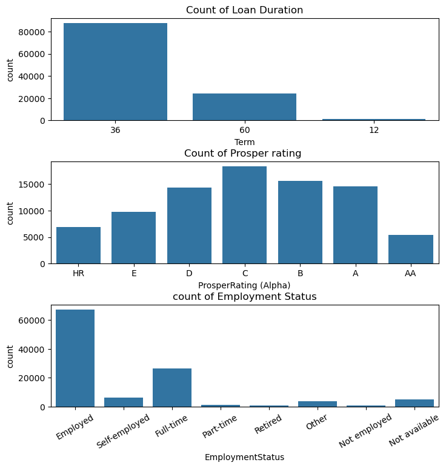

## Observation:

#### Employment Status column:

The most people being issued loan as can be seen from the plot above is the people under the employed category. Followed next by the Fulltime category.Unemployed category is one of the least issued amongst the part_time and retired categories.

#### Prosper rating:

The category with the highest count for prosper rating is the C category and the least category is the AA category.

#### Term:

A majority of the loans were issued for a period of 36months and the least duartion for loan term is 12months.

### Prosper Rating

A custom risk score built using historical Prosper data. The score ranges from 1-10, with 10 being the best, or lowest risk score. Applicable for loans originated after July 2009.

### OBSERVATION

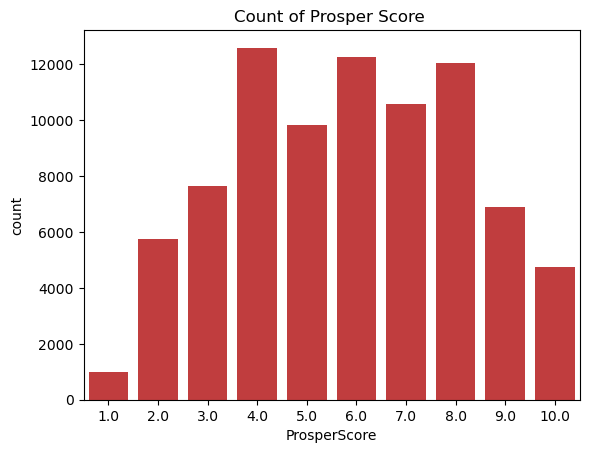

### Delinquencies and amount deliquent

AmountDeliquent: Dollars delinquent at the time the credit profile was pulled. Delinquencieslast 7 years: Number of delinquencies in the past 7 years at the time the credit profile was pulled.